# Credit Card Users Churn Prediction

##### Attrition_Flag vs Total_Relationship_Count

```
Attrition_Flag               0     1    All
Total_Relationship_Count
All                       8500  1627  10127
3                         1905   400   2305
2                          897   346   1243
1                          677   233    910
5                         1664   227   1891
4                         1687   225   1912
6                         1670   196   1866
------------------------------------------------------------------------------------------------------------------------
```

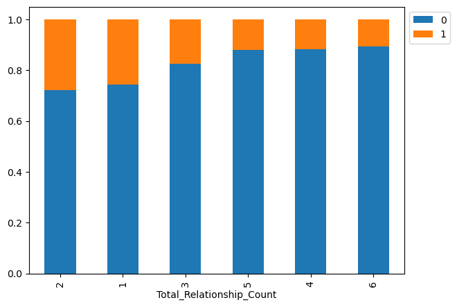

```python
stacked_barplot(data, "Total_Relationship_Count", "Attrition_Flag")
```

- For customers with 1 or 2 relationships with the bank, they are more likely to attrite based on the trends in the data. This shows that customers with fewer products with the bank tend to attrite since they are less engaged with the bank.
- Customers with higher of relationships (3 to 6), there is a clear indication of their lower likelihood to attrite. This shows that the more services and integration a customer has with the bank, the less likely they are to attrite.
- This variable is a good indicator of an inverse relationship between number of relationships and likelihood of attrition, especially when the number of relationships is on the lower and higher side.

##### Attrition_Flag vs Months_on_book

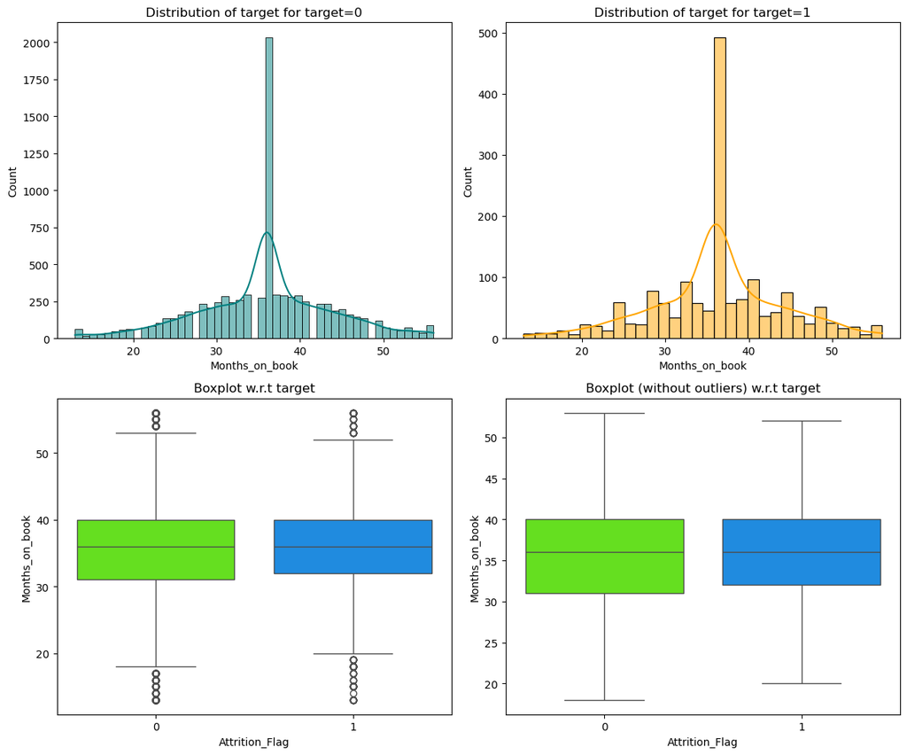

```python
distribution_plot_wrt_target(data, "Months_on_book", "Attrition_Flag")
```

- From the visualizations, there doesn't seem to be a clear indication of whether the number of months the customer is on the bank's books influences their likelihood to attribute.
- The distribution of customers with difference number of months on book is similar for both customers that attrite and continue, and their medians don't different much either. This column is probably not a very useful indicator of attrition.

##### Attrition_Flag vs Customer_Age

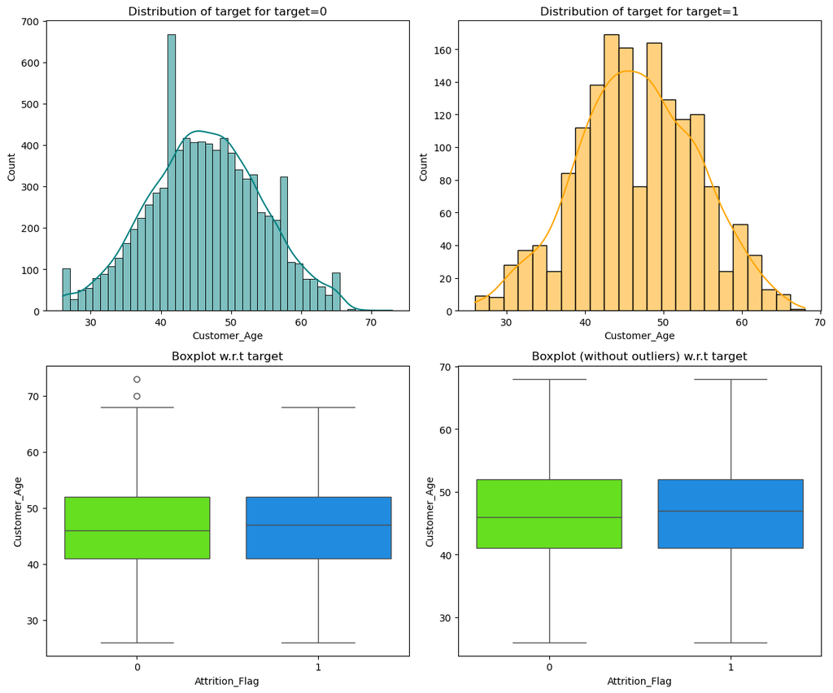

```python
distribution_plot_wrt_target(data, "Customer_Age", "Attrition_Flag")
```

- Customers with a slightly higher age are marginally more likely to attrite. There is a similar overall distribution curve for attrition rate vs the age of the customer, and though there are small patterns, this is likely not a good indicator of attrition.

##### Attrition_Flag vs Total_Revolving_Bal

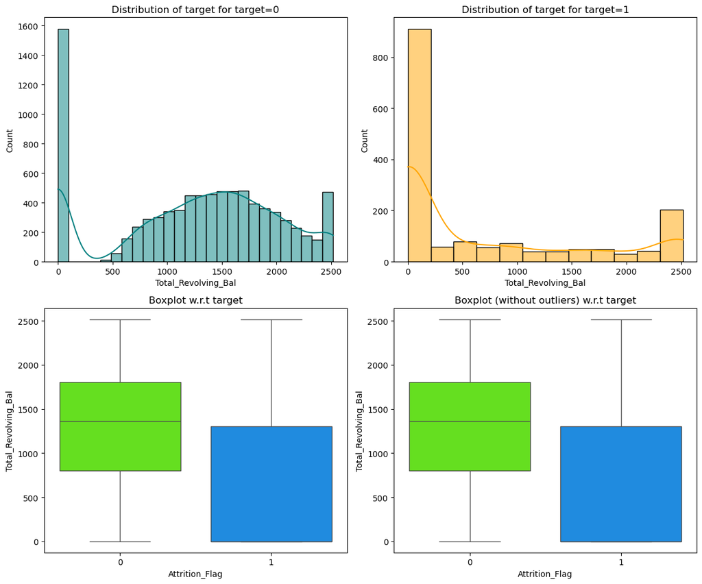

```python
distribution_plot_wrt_target(data, "Total_Revolving_Bal", "Attrition_Flag")
```

- From the visualizations, there is a clear indication of a relationship between total revolving balance and attrition.
- Higher the total revolving balance, the less likely the customers are to attribute.

From the distribution and from the medians in the boxplots, we can see that the customers who attrite have very low or zero revolving balances. This is a strong indicator of attrition.

##### Attrition_Flag vs Credit_Limit

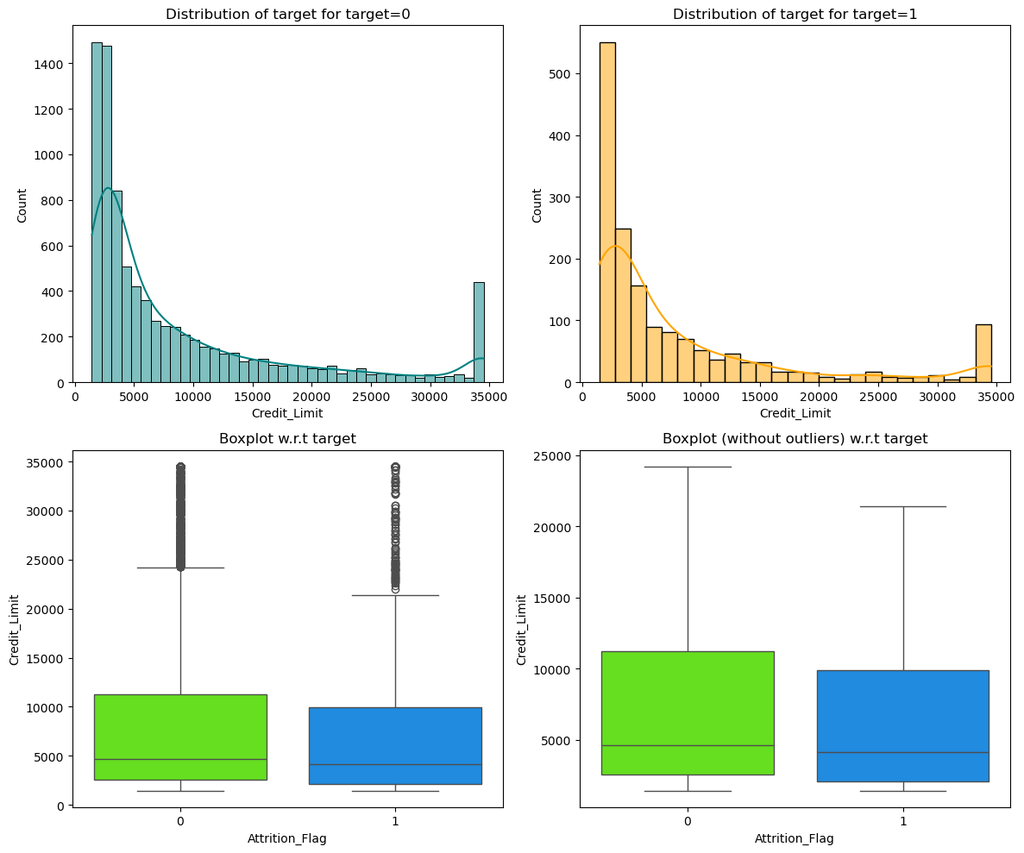

```python
distribution_plot_wrt_target(data, "Credit_Limit", "Attrition_Flag")
```

- The distribution and median credit limit are very similar for customers that both attrite and continue with the bank. Customers with marginally higher credit limit are less likely to attribute but the difference isn't very significant.
- Both distributions have outliers too. It is noted that customers that don't attribute have a higher interquartile range and thus more spread of credit limit.
- Credit Limit is unlikely to be a very useful indicator of attrition.

##### Attrition_Flag vs Total_Trans_Ct

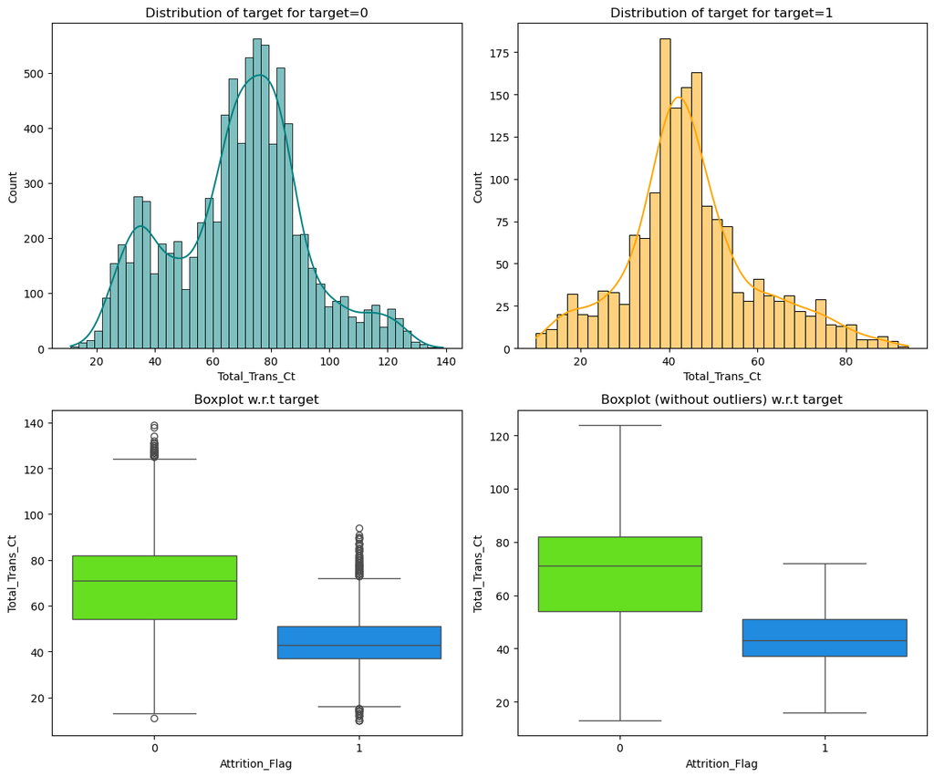

```python
distribution_plot_wrt_target(data, "Total_Trans_Ct", "Attrition_Flag")
```

- There is a strong inverse relationship between total transaction counts and attrition. Customers with higher transaction counts are more likely to continue, and as a result customers with lower total transaction counts are much more likely to attrite.
- The difference in the medians and spreads of the total transaction count between customers who attrited and didn't is significant, with the upper limit of total transaction count of customers who attrited close to the median total transaction count of customer who continued.
- Total transaction count is a strong indicator of attrition, showing a strong association between higher transaction activity and retention.

##### Attrition_Flag vs Total_Trans_Amt

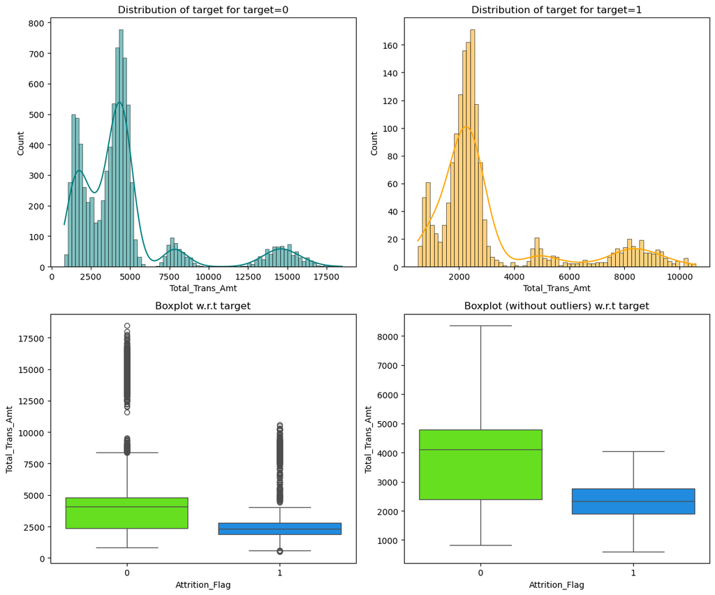

```python
distribution_plot_wrt_target(data, "Total_Trans_Amt", "Attrition_Flag")
```

- There is a fairly similar pattern distribution in the total transaction amount between customers who attrited and those you didn't. However, the spread and range of the customers who didn't attribute is much larger.
- The median total transaction amount of customers who attrited is much lower than those who continued; this pattern is similar to what we saw in Total Transaction Count, since the two are closely related too.
- Hence, this is a good variable to predict attrition in combination with others, demonstrating an inverse relationship between total transaction amount and attrition.

##### Attrition_Flag vs Total_Ct_Chng_Q4_Q1

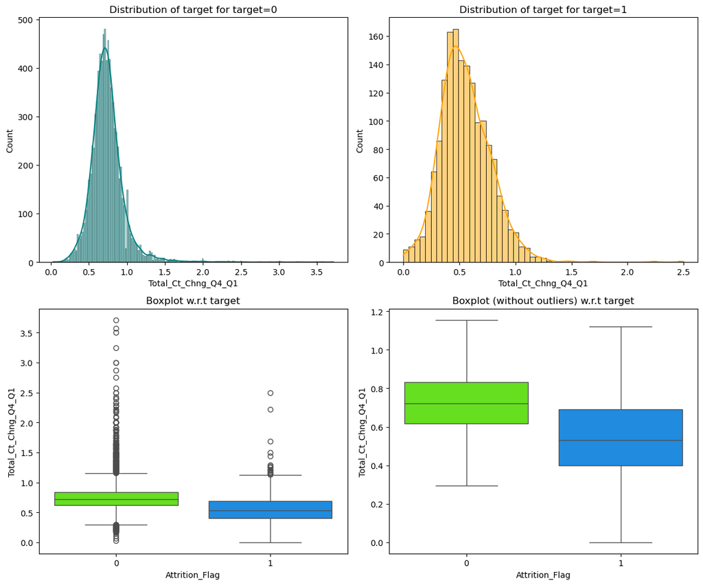

```python
distribution_plot_wrt_target(data, "Total_Ct_Chng_Q4_Q1", "Attrition_Flag")
```

- The distribution of total count change between Q4 and Q1 between customers who attributed and didn't is fairly different. The range and spread of the ratio for attrited customers is lower, and so is the median.
- The median total count change for customers who attrited is around 0.5 whereas for those who continued is about 0.7. This indicates that higher the change, the less likely they are to attrite. It can also be seen that customers who continued have many more outliers than the attrited group.
- This variable is likely a good indicator in combination with others variables to determine if the customer will attrite or not.

##### Attrition_Flag vs Total_Amt_Chng_Q4_Q1

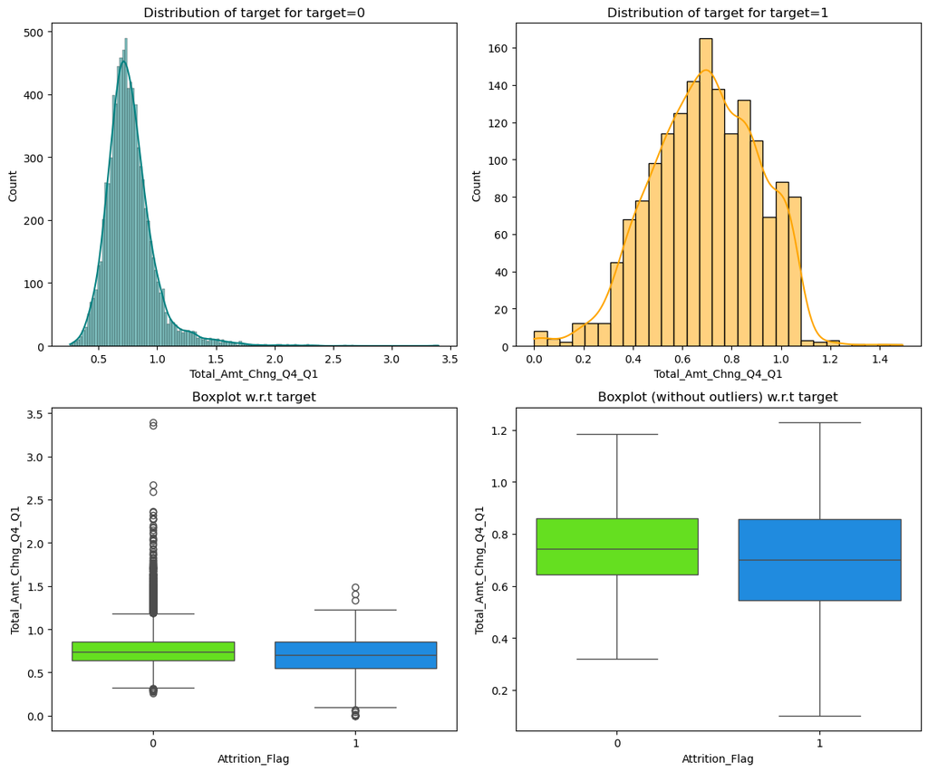

```python
distribution_plot_wrt_target(data, "Total_Amt_Chng_Q4_Q1", "Attrition_Flag")
```

- The distribution of the total amount change between Q4 and Q1 is very similar to total count change, however the medians of the two groups of customers do not vary very much. The distribution of attrited customers is much more concentrated around lower values, wheres customers that continued have a much larger range of values.
- The median total amount change between Q4 and Q1 are both around 0.7 with very slightly differences, which shows that this variable may be a weak indicator of attrition.

##### Attrition_Flag vs Avg_Utilization_Ratio

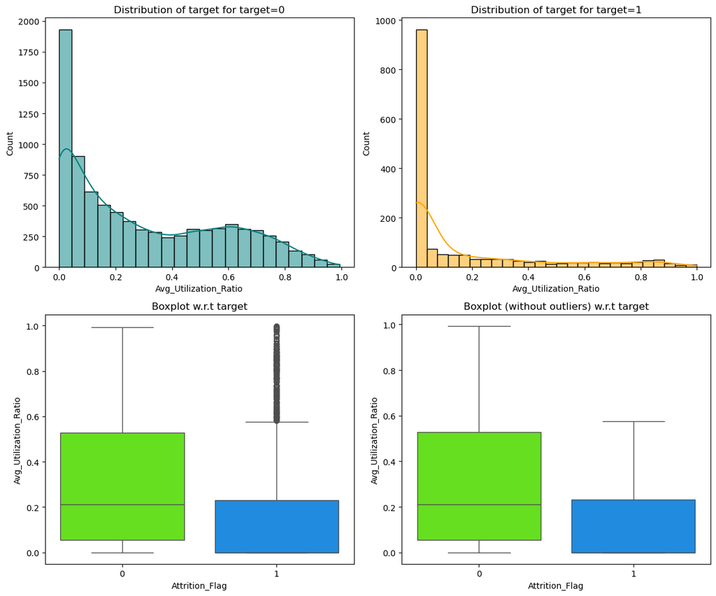

```python
distribution_plot_wrt_target(data, "Avg_Utilization_Ratio", "Attrition_Flag")
```

- The median avg utilization ratio of customers who attrited is 0, significantly lower than that of the customers who continued which is around 0.2.
- The interquartile range of customers who continued is much larger, but the number of outliers in the attrition group is very high, hence while this is a good indicator, it may not be very strong on its own.
- Most of the customers who attrited have an average utilization ratio of 0, and 75% of them have an average utilization ratio of around 0.2 or less, which is the median value for the customers that continued.

##### Attrition_Flag vs Avg_Open_To_Buy

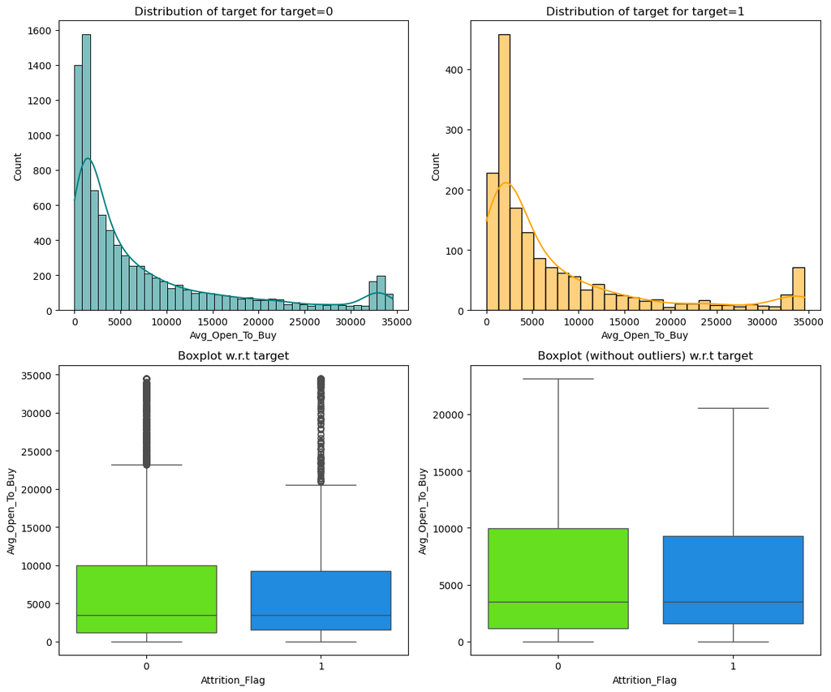

```python
distribution_plot_wrt_target(data, "Avg_Open_To_Buy", "Attrition_Flag")
```

- The Avg Open to Buy for customers that attrited and those who didn't are similar in their median and distribution.
- The interquartile range of the customers who continued seems to be more, but since both groups have many outliers and their distributions and medians are similar, we can say that this variable is not likely a very influential factor in predicting attrition.

#### Bivariate questions

4. How does the change in transaction amount between Q4 and Q1 (`total_ct_change_Q4_Q1`) vary by the customer's account status (`Attrition_Flag`)?

Summarizing the findings from the bivariate analysis, total total count change between Q4 and Q1 differs significantly between customers who attrited and those who didn’t, with attrited customers having a lower median and spread. The median count change for attrited customers is around 0.5, while it’s about 0.7 for those who continued, indicating that a higher count change reduces the likelihood of attrition. This suggests that total count change is a strong predictor of attrition.

5. How does the number of months a customer was inactive in the last 12 months (`Months_Inactive_12_mon`) vary by the customer's account status (`Attrition_Flag`)?

Summarizing the findings from the bivariate analysis, the number of inactive months in the last 12 months shows varying patterns, with customers having 3-5 months of inactivity more likely to attrite, while those with 1 month inactive are more likely to stay. There is no clear linear correlation, as high inactivity does not always indicate attrition. Overall, Months Inactive is a useful variable when combined with other factors to predict attrition.

6. What are the attributes that have a strong correlation with each other?

Summarizing the findings from the correlation heatmap, the attributes show strong relationships with each other are:

- Attrition Flag has the strongest negative correlation with Total Transaction Count (-0.37), meaning more transactions are associated with lower attrition. Other variables it is correlated with are Total Ct Chng Q4-Q1 (-0.29), Total Revolving Balance (-0.26), and a positive correlation with Contacts Count 12 mon (0.20), which may reflect dissatisfaction.
- Customer Age has a strong correlation with Months on Book (0.79), indicating older customers have longer relationships with the bank.
- Credit Limit and Avg Open to Buy have a perfect correlation (1.00), because they are derived from the other.
- Total Transaction Amount and Total Transaction Count are strongly correlated (0.81), intuitively linking more transactions to higher transaction amounts.
- Total Revolving Balance and Avg Utilization Ratio are positively correlated (0.62), showing that higher balances lead to higher utilization rates. Avg Utilization Ratio is also negatively correlated with Credit Limit (-0.48) and Avg Open to Buy (-0.54), reflecting their mathematical relationships as mentioned in the data dictionary.

## Data Pre-processing

### Outlier detection analysis

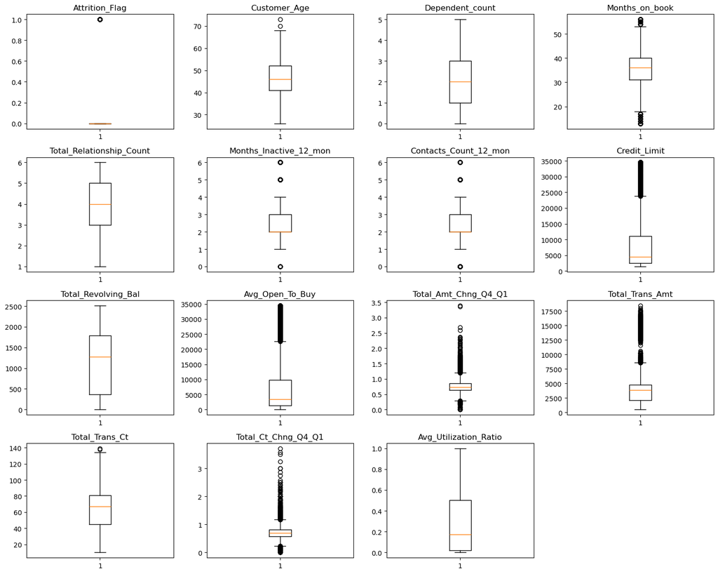

```python
# Checking for outliers using boxplot method
numeric_columns = data.select_dtypes(include=np.number).columns.tolist()

plt.figure(figsize=(15, 12))

for i, variable in enumerate(numeric_columns):
    plt.subplot(4, 4, i + 1)
    plt.boxplot(data[variable], whis=1.5)
    plt.tight_layout()
    plt.title(variable)

plt.show()
```

- With the bloxplots of all the numerical variables we can see the outliers visually that are larger than the third quartile (75th percentile) or smaller than the first quartile (25th percentile).
- Attrition flag is our target variable, and many variables like Dependent count, Total relationship count, Total Revolving Balance, Total Transaction Count and Avg Utilization Ratio have little to no outliers.
- Months on book, Months inactive 12 months and Contact count 12 months are all discrete number variables that indicate a tendency towards a normal distribution but all these numbers are valid and do not cause reason for alarm and are vital in building a model. Customer age has some outliers above 65, because most of the customers are young adults and middle aged adults. This data is still valuable and does not need to be treated.
- Credit Limit has many outliers above the upper whisker of about 25000, while most customers have low to moderate credit limits, some have high limits. Though from our exploratory data analysis, this column is unlikely to be a very strong indicator, it is important to keep customers with different credit limits because they give us insights into customers and their behavior. The same goes for columns Total Amount Change Q4 Q1, Total Count Change Q4 Q1, Total Transaction Amount and Avg Open to Buy. The Avg Utilization Ratio has standardized the values in many of these columns so that we have a good single column with an interpretable ratio. Despite outliers, these values all make sense and will be kept in our analysis.
- The customers with outlier values in many parameters represent valuable insights into customer behavior and if they attrite or not. Hence we will not be removing any outliers.

### Train test data split

```python
# creating the copy of the dataframe before splitting
data_copy = data.copy()

# Dividing data into X and y
X = data_copy.drop(["Attrition_Flag"], axis=1)
y = data_copy["Attrition_Flag"]
```

```python
# first we split data into 2 parts, say temporary and test
X_temp, X_test, y_temp, y_test = train_test_split(
    X, y, test_size=0.2, random_state=5, stratify=y
)

# then we split the temporary set into train and validation
X_train, X_val, y_train, y_val = train_test_split(
    X_temp, y_temp, test_size=0.2, random_state=5, stratify=y_temp
)
```

```python
# Splitting data into training, validation and test set

# first we split data into 2 parts, say temporary and test
X_temp, X_test, y_temp, y_test = train_test_split(
    X, y, test_size=0.2, random_state=1, stratify=y
)

# then we split the temporary set into train and validation
X_train, X_val, y_train, y_val = train_test_split(
    X_temp, y_temp, test_size=0.2, random_state=1, stratify=y_temp
)

print("Shape of train, validation and test set")
print(X_train.shape, X_val.shape, X_test.shape)
```

```
Shape of train, validation and test set
(6480, 19) (1621, 19) (2026, 19)
```

```python
# Checking class balance for whole data, train set, validation set, and test set

print("Target value ratio in y")
print(y.value_counts(1))
print("*" * 80)
print("Target value ratio in y_train")
print(y_train.value_counts(1))
print("*" * 80)
print("Target value ratio in y_val")
print(y_val.value_counts(1))
print("*" * 80)
print("Target value ratio in y_test")
print(y_test.value_counts(1))
print("*" * 80)
```

```
Target value ratio in y
Attrition_Flag
0   0.839
1   0.161
Name: proportion, dtype: float64
Target value ratio in y_train
Attrition_Flag
0   0.839
1   0.161
Name: proportion, dtype: float64
Target value ratio in y_val
Attrition_Flag
0   0.839
1   0.161
Name: proportion, dtype: float64
Target value ratio in y_test
Attrition_Flag
0   0.840
1   0.160
Name: proportion, dtype: float64
```

### Missing value imputation

We will now deal with the missing values in Education level, Marital Status and Income Category

```python
# Missing value imputation is done after splitting the data into train and test to avoid data leakage
#Filling null values of Marital_Status, Education Level and Income Category with the mode using SimpleImputer

imputer = SimpleImputer(strategy='most_frequent')
cols = ['Education_Level', 'Marital_Status', 'Income_Category']

X_train[cols] = imputer.fit_transform(X_train[cols])
X_val[cols] = imputer.transform(X_val[cols])
X_test[cols] = imputer.transform(X_test[cols])
```

```python
# Checking that no column has missing values in train or or validation or test sets
print(X_train.isna().sum())
print("-" * 30)
print(X_val.isna().sum())
print("-" * 30)
print(X_test.isna().sum())
```

```
Customer_Age                0
Gender                      0
Dependent_count             0
Education_Level             0
Marital_Status              0
Income_Category             0
Card_Category               0
Months_on_book              0
Total_Relationship_Count    0
Months_Inactive_12_mon      0
Contacts_Count_12_mon       0
Credit_Limit                0
Total_Revolving_Bal         0
Avg_Open_To_Buy             0
Total_Amt_Chng_Q4_Q1        0
Total_Trans_Amt             0
Total_Trans_Ct              0
Total_Ct_Chng_Q4_Q1         0
Avg_Utilization_Ratio       0
dtype: int64
------------------------------
Customer_Age                0
Gender                      0
Dependent_count             0
Education_Level             0
Marital_Status              0
Income_Category             0
Card_Category               0
Months_on_book              0
Total_Relationship_Count    0
Months_Inactive_12_mon      0
Contacts_Count_12_mon       0
Credit_Limit                0
Total_Revolving_Bal         0
Avg_Open_To_Buy             0
Total_Amt_Chng_Q4_Q1        0
Total_Trans_Amt             0
Total_Trans_Ct              0
Total_Ct_Chng_Q4_Q1         0
Avg_Utilization_Ratio       0
dtype: int64
------------------------------
Customer_Age                0
Gender                      0
Dependent_count             0
Education_Level             0
Marital_Status              0
Income_Category             0
Card_Category               0
Months_on_book              0
Total_Relationship_Count    0
Months_Inactive_12_mon      0
Contacts_Count_12_mon       0
Credit_Limit                0
Total_Revolving_Bal         0
Avg_Open_To_Buy             0
Total_Amt_Chng_Q4_Q1        0
Total_Trans_Amt             0
Total_Trans_Ct              0
Total_Ct_Chng_Q4_Q1         0
Avg_Utilization_Ratio       0
dtype: int64
```

### Encoding categorical variables

```python
#Creating dummy variables for all the categorical variables in train, validation and test data sets

X_train = pd.get_dummies(X_train, drop_first=True)
X_val = pd.get_dummies(X_val, drop_first=True)
X_test = pd.get_dummies(X_test, drop_first=True)

print("Shape of train, validation and test set")
print(X_train.shape, X_val.shape, X_test.shape)
```

```
Shape of train, validation and test set
(6480, 29) (1621, 29) (2026, 29)
```

## Model Building

### Model evaluation criterion

Model can make wrong predictions as:

- Predicting a customer will attrite and the customer doesn't attrite
- Predicting a customer will not attrite and the customer attrites

Which case is more important?

- Predicting that customer will not attrite but he attrites i.e. losing on a valuable customer or asset.

**How to reduce this loss i.e need to reduce False Negatives??**

- Bank would want Recall to be maximized, greater the Recall higher the chances of minimizing false negatives. Hence, the focus should be on increasing Recall or minimizing the false negatives or in other words identifying the true positives(i.e. Class 1) so that the bank can retain their valuable customers by identifying the customers who are at risk of attrition.

**Let's define a function to output different metrics (including recall) on the train and test set and a function to show confusion matrix so that we do not have to use the same code repetitively while evaluating models.**

```python
# defining a function to compute different metrics to check performance of a classification model built using sklearn
def model_performance_classification_sklearn(model, predictors, target):
    """
    Function to compute different metrics to check classification model performance

    model: classifier
    predictors: independent variables
    target: dependent variable
    """

    # predicting using the independent variables
    pred = model.predict(predictors)

    acc = accuracy_score(target, pred)  # to compute Accuracy
    recall = recall_score(target, pred)  # to compute Recall
    precision = precision_score(target, pred)  # to compute Precision
    f1 = f1_score(target, pred)  # to compute F1-score

    # creating a dataframe of metrics
    df_perf = pd.DataFrame(
        {
            "Accuracy": acc,
            "Recall": recall,
            "Precision": precision,
            "F1": f1

        },
        index=[0],
    )

    return df_perf
```

### Model Building with original data

Sample code for model building with original data

```python
models = []  # Empty list to store all the models
original_performance_train = []
original_performance_val = []

# Appending models into the list
models.append(("Bagging", BaggingClassifier(random_state=1)))
models.append(("Random forest", RandomForestClassifier(random_state=1)))
models.append(("Decision Tree", DecisionTreeClassifier(random_state=1)))
models.append(("AdaBoost", AdaBoostClassifier(random_state=1)))
models.append(("GradientBoost", GradientBoostingClassifier(random_state=1)))
models.append(("XGBoost", XGBClassifier(random_state=1)))


# Fit, predict and print the recall for training data
print("\n" "Training Performance:" "\n")
for name, model in models:
    model.fit(X_train, y_train)
    scores = recall_score(y_train, model.predict(X_train))
    original_performance_train.append([name,scores])
    print("{}: {}".format(name, scores))

# Fit, predict and print the recall for validation data
print("\n" "Validation Performance:" "\n")

for name, model in models:
    model.fit(X_train, y_train)
    scores_val = recall_score(y_val, model.predict(X_val))
    original_performance_val.append([name,scores_val])
    print("{}: {}".format(name, scores_val))
```

```
Training Performance:

Bagging: 0.9769452449567724
Random forest: 1.0
Decision Tree: 1.0
AdaBoost: 0.8443804034582133
GradientBoost: 0.8789625360230547
XGBoost: 1.0

Validation Performance:

Bagging: 0.8160919540229885
Random forest: 0.8007662835249042
Decision Tree: 0.8314176245210728
AdaBoost: 0.842911877394636
GradientBoost: 0.8735632183908046
XGBoost: 0.8773946360153256
```

```python
print("\nTraining and Validation Performance Difference:\n")

for name, model in models:
    model.fit(X_train, y_train)
    scores_train = recall_score(y_train, model.predict(X_train))
    scores_val = recall_score(y_val, model.predict(X_val))
    difference1 = scores_train - scores_val
    print("{}: Training Score: {:.4f}, Validation Score: {:.4f}, Difference: {:.4f}".format(name, scores_train, scores_val, difference1))
```

```
Training and Validation Performance Difference:

Bagging: Training Score: 0.9769, Validation Score: 0.8161, Difference: 0.1609
Random forest: Training Score: 1.0000, Validation Score: 0.8008, Difference: 0.1992
Decision Tree: Training Score: 1.0000, Validation Score: 0.8314, Difference: 0.1686
AdaBoost: Training Score: 0.8444, Validation Score: 0.8429, Difference: 0.0015
GradientBoost: Training Score: 0.8790, Validation Score: 0.8736, Difference: 0.0054
XGBoost: Training Score: 1.0000, Validation Score: 0.8774, Difference: 0.1226
```

Models with original data performance observations:

### Model Building with Oversampled data

```python
#Using the SMOTE library to oversample the Not Attrited customers

# Checking counts of target variable before oversampling
print("Before Oversampling, counts of label 'Yes': {}".format(sum(y_train == 1)))
print("Before Oversampling, counts of label 'No': {} \n".format(sum(y_train == 0)))

sm = SMOTE(
    sampling_strategy=1, k_neighbors=5, random_state=1
)  # Synthetic Minority Over Sampling Technique
X_train_over, y_train_over = sm.fit_resample(X_train, y_train)

# Checking counts of target variable after oversampling
print("After Oversampling, counts of label 'Yes': {}".format(sum(y_train_over == 1)))
print("After Oversampling, counts of label 'No': {} \n".format(sum(y_train_over == 0)))

# Checking the shape of the train and target variable after oversampling
print("After Oversampling, the shape of train_X: {}".format(X_train_over.shape))
print("After Oversampling, the shape of train_y: {} \n".format(y_train_over.shape))
```

```
Before Oversampling, counts of label 'Yes': 1041
Before Oversampling, counts of label 'No': 5439

After Oversampling, counts of label 'Yes': 5439
After Oversampling, counts of label 'No': 5439

After Oversampling, the shape of train_X: (10878, 29)
After Oversampling, the shape of train_y: (10878,)
```

```python
models = []  # Empty list to store all the models
oversampling_performance_train = []
oversampling_performance_val = []

# Appending models into the list
models.append(("Bagging", BaggingClassifier(random_state=1)))
models.append(("Random forest", RandomForestClassifier(random_state=1)))
models.append(("Decision Tree", DecisionTreeClassifier(random_state=1)))
models.append(("AdaBoost", AdaBoostClassifier(random_state=1)))
models.append(("GradientBoost", GradientBoostingClassifier(random_state=1)))
models.append(("XGBoost", XGBClassifier(random_state=1)))


# Fit, predict and print the recall for training data
print("\n" "Training Performance:" "\n")
for name, model in models:
    model.fit(X_train_over, y_train_over)
    scores = recall_score(y_train_over, model.predict(X_train_over))
    oversampling_performance_train.append([name,scores])
    print("{}: {}".format(name, scores))


# Fit, predict and print the recall for validation data
print("\n" "Validation Performance:" "\n")

for name, model in models:
    model.fit(X_train_over, y_train_over)
    scores = recall_score(y_val, model.predict(X_val))
    oversampling_performance_val.append([name,scores])
    print("{}: {}".format(name, scores))
```

```
Training Performance:

Bagging: 0.9977937120794264
Random forest: 1.0
Decision Tree: 1.0
AdaBoost: 0.9648832505975363
GradientBoost: 0.9797756940614083
XGBoost: 1.0

Validation Performance:

Bagging: 0.8467432950191571
Random forest: 0.8659003831417624
Decision Tree: 0.8275862068965517
AdaBoost: 0.8888888888888888
GradientBoost: 0.896551724137931
XGBoost: 0.9080459770114943
```

```python
print("\nTraining and Validation Performance Difference:\n")

for name, model in models:
    model.fit(X_train_over, y_train_over)
    scores_train = recall_score(y_train_over, model.predict(X_train_over))
    scores_val = recall_score(y_val, model.predict(X_val))
    difference1 = scores_train - scores_val
    print("{}: Training Score: {:.4f}, Validation Score: {:.4f}, Difference: {:.4f}".format(name, scores_train, scores_val, difference1))
```

```
Training and Validation Performance Difference:

Bagging: Training Score: 0.9978, Validation Score: 0.8467, Difference: 0.1511
Random forest: Training Score: 1.0000, Validation Score: 0.8659, Difference: 0.1341
Decision Tree: Training Score: 1.0000, Validation Score: 0.8276, Difference: 0.1724
AdaBoost: Training Score: 0.9649, Validation Score: 0.8889, Difference: 0.0760
GradientBoost: Training Score: 0.9798, Validation Score: 0.8966, Difference: 0.0832
XGBoost: Training Score: 1.0000, Validation Score: 0.9080, Difference: 0.0920
```

### Model Building with Undersampled data

```python
# Checking counts of target variable before undersampling
print("Before Under Sampling, counts of label 'Yes': {}".format(sum(y_train == 1)))
print("Before Under Sampling, counts of label 'No': {} \n".format(sum(y_train == 0)))

# Random undersampler for under sampling the data
rus = RandomUnderSampler(random_state=1, sampling_strategy=1)
X_train_un, y_train_un = rus.fit_resample(X_train, y_train)

# Checking counts of target variable after undersampling
print("After Under Sampling, counts of label 'Yes': {}".format(sum(y_train_un == 1)))
print("After Under Sampling, counts of label 'No': {} \n".format(sum(y_train_un == 0)))

# Checking the shape of the train and target variable after undersampling
print("After Under Sampling, the shape of train_X: {}".format(X_train_un.shape))
print("After Under Sampling, the shape of train_y: {} \n".format(y_train_un.shape))
```

```
Before Under Sampling, counts of label 'Yes': 1041
Before Under Sampling, counts of label 'No': 5439

After Under Sampling, counts of label 'Yes': 1041
After Under Sampling, counts of label 'No': 1041

After Under Sampling, the shape of train_X: (2082, 29)
After Under Sampling, the shape of train_y: (2082,)
```

```python
models = []  # Empty list to store all the models
undersampling_performance_train = []
undersampling_performance_val = []

# Appending models into the list
models.append(("Bagging", BaggingClassifier(random_state=1)))
models.append(("Random forest", RandomForestClassifier(random_state=1)))
models.append(("Decision Tree", DecisionTreeClassifier(random_state=1)))
models.append(("AdaBoost", AdaBoostClassifier(random_state=1)))
models.append(("GradientBoost", GradientBoostingClassifier(random_state=1)))
models.append(("XGBoost", XGBClassifier(random_state=1)))

# Fit, predict and print the recall for training data
print("\n" "Training Performance:" "\n")
for name, model in models:
    model.fit(X_train_un, y_train_un)
    scores = recall_score(y_train_un, model.predict(X_train_un))
    undersampling_performance_train.append([name,scores])
    print("{}: {}".format(name, scores))


# Fit, predict and print the recall for validation data
print("\n" "Validation Performance:" "\n")

for name, model in models:
    model.fit(X_train_un, y_train_un)
    scores = recall_score(y_val, model.predict(X_val))
    undersampling_performance_val.append([name,scores])
    print("{}: {}".format(name, scores))
```

```
Training Performance:

Bagging: 0.9951969260326609
Random forest: 1.0
Decision Tree: 1.0
AdaBoost: 0.9567723342939481
GradientBoost: 0.9865513928914506
XGBoost: 1.0

Validation Performance:

Bagging: 0.9386973180076629
Random forest: 0.9578544061302682
Decision Tree: 0.89272030651341
AdaBoost: 0.9540229885057471
GradientBoost: 0.9540229885057471
XGBoost: 0.9616858237547893
```

```python
print("\nTraining and Validation Performance Difference:\n")

for name, model in models:
    model.fit(X_train_un, y_train_un)
    scores_train = recall_score(y_train_un, model.predict(X_train_un))
    scores_val = recall_score(y_val, model.predict(X_val))
    difference1 = scores_train - scores_val
    print("{}: Training Score: {:.4f}, Validation Score: {:.4f}, Difference: {:.4f}".format(name, scores_train, scores_val, difference1))
```

```
Training and Validation Performance Difference:

Bagging: Training Score: 0.9952, Validation Score: 0.9387, Difference: 0.0565
Random forest: Training Score: 1.0000, Validation Score: 0.9579, Difference: 0.0421
Decision Tree: Training Score: 1.0000, Validation Score: 0.8927, Difference: 0.1073
AdaBoost: Training Score: 0.9568, Validation Score: 0.9540, Difference: 0.0027
GradientBoost: Training Score: 0.9866, Validation Score: 0.9540, Difference: 0.0325
XGBoost: Training Score: 1.0000, Validation Score: 0.9617, Difference: 0.0383
```

Models with undersampled data performance observations:

- Bagging: The model is performing well with high training and validation scores and performing better than in the previous scenarios with just a difference of 0.0565.
- Random Forest: With a persistent perfect training score, a reduced difference of 0.0421, this model is still likely overfitting but performing much better than before. It shows the highest validation score so far among the random forest models that shows promise.
- Decision Tree: Once again with a perfect training score, this model likely isn't very food because of the substantial difference of 0.1073 compared to the other models and hence is overfitting. While this model has done better with undersampling, it is still not good enough at generalizing compared to the other models we have available.
- AdaBoost: The difference between training and validation scores is only 0.0027, meaning that the performance between training and validation is nearly identical. This is a strong model and has potential to be very useful.
- GradientBoost: This model shows a strong performance with training score 0.9866 and validation score 0.9540, with only a small difference of 0.0325, performing well on unseen data and not overfitting.
- XGBoost: Despite once again having a perfect training score of 1.0, it has a high validation score of 0.9617 and is likely a very useful model despite the minor overfitting which could be fixed with some tuning.

Despite increase in performance metrics, the undersampled data has a lot less data points in the train dataset, about a fifth of the data in the oversampled dataset, making the robustness potentially questionable when it sees a lot more data. Hence these models have to be taken with a grain of salt and further fine tuned.

### Summarize performance of all models

```python
# Create a table with all the performance variables original performance train and val, oversampling performance train and val, undersampling performance train adn val
original_performance_train_df = pd.DataFrame(original_performance_train, columns=['Model', 'Score_Original_Train'])
original_performance_val_df = pd.DataFrame(original_performance_val, columns=['Model', 'Score_Original_Val'])
oversampling_performance_train_df = pd.DataFrame(oversampling_performance_train, columns=['Model', 'Score_Oversampling_Train'])
oversampling_performance_val_df = pd.DataFrame(oversampling_performance_val, columns=['Model', 'Score_Oversampling_Val'])
undersampling_performance_train_df = pd.DataFrame(undersampling_performance_train, columns=['Model', 'Score_Undersampling_Train'])
undersampling_performance_val_df = pd.DataFrame(undersampling_performance_val, columns=['Model', 'Score_Undersampling_Val'])

# Create a table with all the performance variables
performance = original_performance_train_df
performance = pd.merge(performance, original_performance_val_df, on='Model')
performance = pd.merge(performance, oversampling_performance_train_df, on='Model')
performance = pd.merge(performance, oversampling_performance_val_df, on='Model')
performance = pd.merge(performance, undersampling_performance_train_df, on='Model')
performance = pd.merge(performance, undersampling_performance_val_df, on='Model')


performance
```

|  | Model | Score_Original_Train | Score_Original_Val | Score_Oversampling_Train | Score_Oversampling_Val | Score_Undersampling_Train | Score_Undersampling_Val |
| --- | --- | --- | --- | --- | --- | --- | --- |
| 0 | Bagging | 0.977 | 0.816 | 0.998 | 0.847 | 0.995 | 0.939 |
| 1 | Random forest | 1.000 | 0.801 | 1.000 | 0.866 | 1.000 | 0.958 |
| 2 | Decision Tree | 1.000 | 0.831 | 1.000 | 0.828 | 1.000 | 0.893 |
| 3 | AdaBoost | 0.844 | 0.843 | 0.965 | 0.889 | 0.957 | 0.954 |
| 4 | GradientBoost | 0.879 | 0.874 | 0.980 | 0.897 | 0.987 | 0.954 |
| 5 | XGBoost | 1.000 | 0.877 | 1.000 | 0.908 | 1.000 | 0.962 |

### HyperparameterTuning

#### Sample Parameter Grids

**Note**

1. Sample parameter grids have been provided to do necessary hyperparameter tuning. These sample grids are expected to provide a balance between model performance improvement and execution time. One can extend/reduce the parameter grid based on execution time and system configuration.
- Please note that if the parameter grid is extended to improve the model performance further, the execution time will increase
- For Gradient Boosting:

```
param_grid = {
    "init": [AdaBoostClassifier(random_state=1),DecisionTreeClassifier(random_state=1)],
    "n_estimators": np.arange(50,110,25),
    "learning_rate": [0.01,0.1,0.05],
    "subsample":[0.7,0.9],
    "max_features":[0.5,0.7,1],
}
```

- For Adaboost:

```
param_grid = {
    "n_estimators": np.arange(50,110,25),
    "learning_rate": [0.01,0.1,0.05],
    "base_estimator": [
        DecisionTreeClassifier(max_depth=2, random_state=1),
        DecisionTreeClassifier(max_depth=3, random_state=1),
    ],
}
```

- For Bagging Classifier:

```
param_grid = {
    'max_samples': [0.8,0.9,1],
    'max_features': [0.7,0.8,0.9],
    'n_estimators' : [30,50,70],
}
```

- For Random Forest:

```
param_grid = {
    "n_estimators": [50,110,25],
    "min_samples_leaf": np.arange(1, 4),
    "max_features": [np.arange(0.3, 0.6, 0.1),'sqrt'],
    "max_samples": np.arange(0.4, 0.7, 0.1)
}
```

- For Decision Trees:

```
param_grid = {
    'max_depth': np.arange(2,6),
    'min_samples_leaf': [1, 4, 7],
    'max_leaf_nodes' : [10, 15],
    'min_impurity_decrease': [0.0001,0.001]
}
```

- For XGBoost (optional):

```
param_grid={'n_estimators':np.arange(50,110,25),
            'scale_pos_weight':[1,2,5],
            'learning_rate':[0.01,0.1,0.05],
            'gamma':[1,3],
            'subsample':[0.7,0.9]
}
```

#### Tuning XGBoost with undersampled data

```python
%%time

# defining model
Model = XGBClassifier(random_state=1,eval_metric='logloss')

#Parameter grid to pass in RandomSearchCV
param_grid={'n_estimators':np.arange(50,110,25),
            'scale_pos_weight':[1,2,5],
            'learning_rate':[0.01,0.1,0.05],
            'gamma':[1,3],
            'subsample':[0.7,0.9]
           }

# Type of scoring used to compare parameter combinations
scorer = metrics.make_scorer(metrics.recall_score)

#Calling RandomizedSearchCV
randomized_cv = RandomizedSearchCV(estimator=Model, param_distributions=param_grid, n_iter=50, n_jobs = -1, scoring=scorer, cv=5, random_state=1)

#Fitting parameters in RandomizedSearchCV
randomized_cv.fit(X_train_un,y_train_un)

print("Best parameters are {} with CV score={}:" .format(randomized_cv.best_params_,randomized_cv.best_score_))
```

```
Best parameters are {'subsample': 0.9, 'scale_pos_weight': 5, 'n_estimators': 50, 'learning_rate': 0.01, 'gamma': 3} with CV score=0.999043062200957:
CPU times: user 1.31 s, sys: 354 ms, total: 1.66 s
Wall time: 14.9 s
```

```python
tuned_xgb = XGBClassifier(
    random_state=1,
    eval_metric="logloss",
    subsample=0.9,
    scale_pos_weight=5,
    n_estimators=50,
    learning_rate=0.01,
    gamma=3,
)

tuned_xgb.fit(X_train_un, y_train_un)
```

```
XGBClassifier(base_score=None, booster=None, callbacks=None,
              colsample_bylevel=None, colsample_bynode=None,
              colsample_bytree=None, device=None, early_stopping_rounds=None,
              enable_categorical=False, eval_metric='logloss',
              feature_types=None, gamma=3, grow_policy=None,
              importance_type=None, interaction_constraints=None,
              learning_rate=0.01, max_bin=None, max_cat_threshold=None,
              max_cat_to_onehot=None, max_delta_step=None, max_depth=None,
              max_leaves=None, min_child_weight=None, missing=nan,
              monotone_constraints=None, multi_strategy=None, n_estimators=50,
              n_jobs=None, num_parallel_tree=None, random_state=1, ...)
```

```python
xgb_train = model_performance_classification_sklearn(tuned_xgb, X_train_un, y_train_un)
xgb_train
```

|  | Accuracy | Recall | Precision | F1 |
| --- | --- | --- | --- | --- |
| 0 | 0.773 | 1.000 | 0.688 | 0.815 |

```python
xgb_val = model_performance_classification_sklearn(tuned_xgb, X_val, y_val)
xgb_val
```

|  | Accuracy | Recall | Precision | F1 |
| --- | --- | --- | --- | --- |
| 0 | 0.593 | 0.996 | 0.283 | 0.441 |

- On the training set the model achieves a perfect recall but it's Precision and F1 score suggests there is a trade off as it is also predicting many false positives.
- On the validation dataset the model achieves a very high recall of 0.996 which is excellent but the Precision drops significantly to 0.283 which means it is not generalizing the data well enough and is focussed too much on Recall without a decent balance.

#### Tuning AdaBoost with undersampled data

```python
%%time

# defining model
Model = AdaBoostClassifier(random_state=1)

# Parameter grid to pass in RandomSearchCV
param_grid = {
    "n_estimators": np.arange(50,110,25),
    "learning_rate": [0.01,0.1,0.05],
    "estimator": [
        DecisionTreeClassifier(max_depth=2, random_state=1),
        DecisionTreeClassifier(max_depth=3, random_state=1),
    ],
}

# Type of scoring used to compare parameter combinations
scorer = metrics.make_scorer(metrics.recall_score)

#Calling RandomizedSearchCV
randomized_cv = RandomizedSearchCV(estimator=Model, param_distributions=param_grid, n_jobs = -1, n_iter=50, scoring=scorer, cv=5, random_state=1)

#Fitting parameters in RandomizedSearchCV
randomized_cv.fit(X_train_un,y_train_un) ## Complete the code to fit the model on original data

print("Best parameters are {} with CV score={}:" .format(randomized_cv.best_params_,randomized_cv.best_score_))
```

```
Best parameters are {'n_estimators': 100, 'learning_rate': 0.05, 'estimator': DecisionTreeClassifier(max_depth=3, random_state=1)} with CV score=0.9519782848730218:
CPU times: user 1.08 s, sys: 57.3 ms, total: 1.14 s
Wall time: 13.1 s
```

```python
tuned_adb = AdaBoostClassifier(
     n_estimators= 100,
     learning_rate= 0.05,
     base_estimator= DecisionTreeClassifier(max_depth=3, random_state=1)
)

tuned_adb.fit(X_train_un, y_train_un)
```

```
AdaBoostClassifier(base_estimator=DecisionTreeClassifier(max_depth=3,
                                                         random_state=1),
                   learning_rate=0.05, n_estimators=100)
```

```python
adb_train = model_performance_classification_sklearn(tuned_adb, X_train_un, y_train_un)
adb_train
```

|  | Accuracy | Recall | Precision | F1 |
| --- | --- | --- | --- | --- |
| 0 | 0.980 | 0.985 | 0.975 | 0.980 |

```python
adb_val = model_performance_classification_sklearn(tuned_adb, X_val, y_val)
adb_val
```

|  | Accuracy | Recall | Precision | F1 |
| --- | --- | --- | --- | --- |
| 0 | 0.944 | 0.973 | 0.754 | 0.849 |

- In the training dataset there is a high recall of 0.985 and also high values in all over metrics like Accuracy, Precision and F1 which shows that the model is not only accurate and not overfit but is well balanced. A strong F1 of 0.980 shows a good balance between Precision and Recall while the high recall keeps our model fulfilling our priority of minimizng false negatives.
- In the validation set the recall remains high at 0.973 and the Precision and F1 drops, indicating that the model sacrifices predicting some false positives in order to generalize well enough to get a high recall. The F1 store is still fairly high and shows that this model is strong even on unseen data.

#### Tuning Random Forest with undersampled data

```python
%%time

# defining model
Model = RandomForestClassifier(random_state=1)

# Parameter grid to pass in RandomSearchCV
param_grid = {
    "n_estimators": [50,110,25],
    "min_samples_leaf": np.arange(1, 4),
    "max_features": [np.arange(0.3, 0.6, 0.1),'sqrt'],
    "max_samples": np.arange(0.4, 0.7, 0.1)
}

# Type of scoring used to compare parameter combinations
scorer = metrics.make_scorer(metrics.recall_score)

#Calling RandomizedSearchCV
randomized_cv = RandomizedSearchCV(estimator=Model, param_distributions=param_grid, n_jobs = -1, n_iter=50, scoring=scorer, cv=5, random_state=1)

#Fitting parameters in RandomizedSearchCV
randomized_cv.fit(X_train_un,y_train_un) ## Complete the code to fit the model on original data

print("Best parameters are {} with CV score={}:" .format(randomized_cv.best_params_,randomized_cv.best_score_))
```

```
Best parameters are {'n_estimators': 50, 'min_samples_leaf': 2, 'max_samples': 0.6, 'max_features': 'sqrt'} with CV score=0.9299135075450866:
CPU times: user 540 ms, sys: 49.9 ms, total: 590 ms
Wall time: 6.08 s
```

```python
tuned_rf = RandomForestClassifier(
    random_state=1,
    n_estimators= 50,
    min_samples_leaf= 2,
    max_features= 'sqrt',
    max_samples=0.6
)

tuned_rf.fit(X_train_un, y_train_un)
```

```
RandomForestClassifier(max_samples=0.6, min_samples_leaf=2, n_estimators=50,
                       random_state=1)
```

```python
rf_train = model_performance_classification_sklearn(tuned_rf, X_train_un, y_train_un)
rf_train
```

|  | Accuracy | Recall | Precision | F1 |
| --- | --- | --- | --- | --- |
| 0 | 0.984 | 0.989 | 0.978 | 0.984 |

```python
rf_val = model_performance_classification_sklearn(tuned_rf, X_val, y_val)
rf_val
```

|  | Accuracy | Recall | Precision | F1 |
| --- | --- | --- | --- | --- |
| 0 | 0.928 | 0.935 | 0.711 | 0.808 |

- In the training dataset, there is a high recall of 0.989 which has reduced the overfitting compared to before tuning the hyperparameters and also showing very high Precision and F1.
- In the validation set the Recall continues to be high at 0.935 and though Precision has dropped significantly, the F1 score is still decently high and shows that we have a respectable balance between the two metrics. Since we are optimizing our hyperparameters in all three cases to maximize Recall, it is not surprising that the model has sacrificed a little bit of its performance on Precision.

## Model Comparison and Final Model Selection

```python
# Comparing the performance of all the models on training data

models_train_comp_df = pd.concat(
    [
        xgb_train.T,
        adb_train.T,
        rf_train.T,
    ],
    axis=1,
)
models_train_comp_df.columns = [
    "XGBoost trained with Undersampled data",
    "AdaBoost trained with Undersampled data",
    "Random Forest trained with Undersampled data",
]
print("Training performance comparison:")
models_train_comp_df
```

```
Training performance comparison:
```

|  | XGBoost trained with Undersampled data | AdaBoost trained with Undersampled data | Random Forest trained with Undersampled data |
| --- | --- | --- | --- |
| Accuracy | 0.773 | 0.980 | 0.984 |
| Recall | 1.000 | 0.985 | 0.989 |
| Precision | 0.688 | 0.975 | 0.978 |
| F1 | 0.815 | 0.980 | 0.984 |

```python
# Comparing the performance of all the models on validation data

models_train_comp_df = pd.concat(
    [
        xgb_val.T,
        adb_val.T,
        rf_val.T,
    ],
    axis=1,
)
models_train_comp_df.columns = [
    "XGBoost validated with Undersampled data",
    "AdaBoost validated with Undersampled data",
    "Random Forest validated with Undersampled data",
]
print("Validation performance comparison:")
models_train_comp_df
```

```
Validation performance comparison:
```

|  | XGBoost validated with Undersampled data | AdaBoost validated with Undersampled data | Random Forest validated with Undersampled data |
| --- | --- | --- | --- |
| Accuracy | 0.593 | 0.944 | 0.928 |
| Recall | 0.996 | 0.973 | 0.935 |
| Precision | 0.283 | 0.754 | 0.711 |
| F1 | 0.441 | 0.849 | 0.808 |

Comparing all the models, across training and validation sets, here are the conclusions by machine learning algorithm:

- XGBoost: The recall is almost perfect and impeccable in both training and data, but the model significantly compromises on balancing Precision and could be identifying too many false positives. While our priority is to minimize recall, having too high a value for false positives isn't ideal either because the company could be focussed on retaining many customers who it thinks will attrite but don't end up attriting.
- AdaBoost: This model offers the best balance between recall and precision while still priotizing recall, making it a strong all round performing with few trade-offs and good at generalizing even on unseen data.
- Random Forest: It provides a strong performance in both datasets and also does not sacrifice too much on identifying too many false positives. Though if we had to compare it with AdaBoost, we would probably go for the model with higher Recall, Precision and F1 though they are only slightly higher.

Since we want to maximize Recall, reduce overfitting and focus on not sacrificing the predicting power of the model across different types of erroneous predictions, the model that is chosen in the end is **AdaBoost trained with Undersampled data**

### Feature Importance

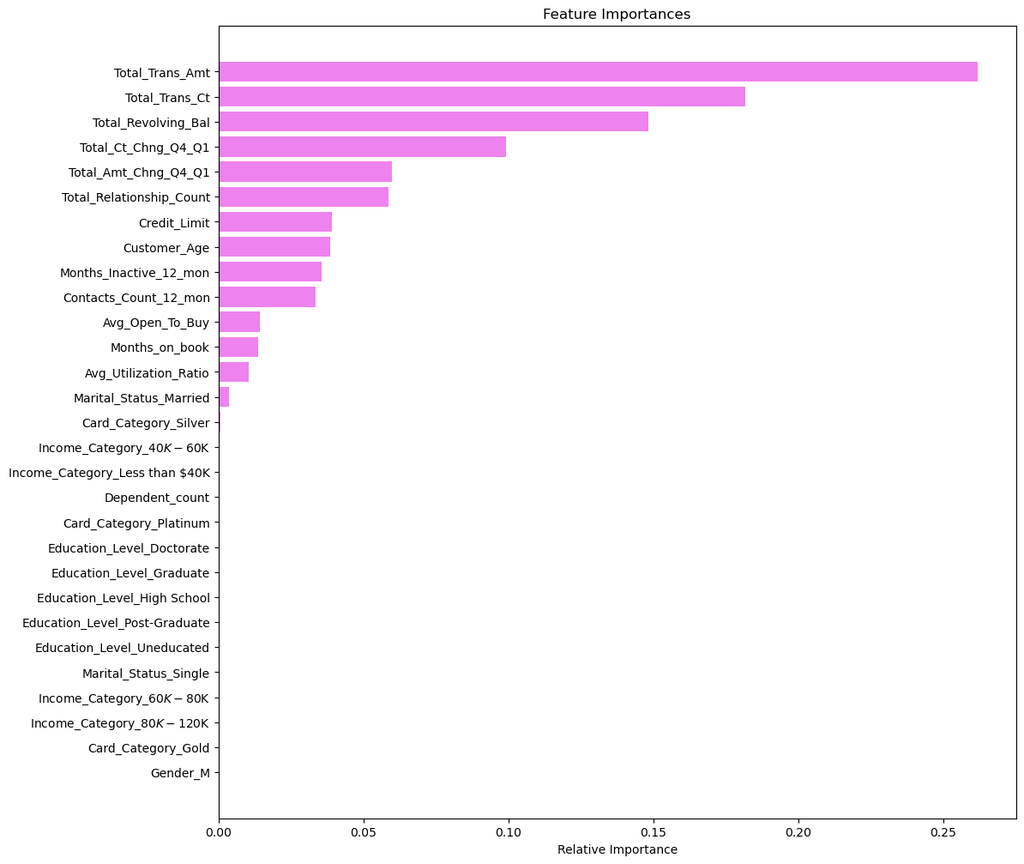

```python
feature_names = X_train_un.columns
importances =  tuned_adb.feature_importances_
indices = np.argsort(importances)

plt.figure(figsize=(12, 12))
plt.title("Feature Importances")
plt.barh(range(len(indices)), importances[indices], color="violet", align="center")
plt.yticks(range(len(indices)), [feature_names[i] for i in indices])
plt.xlabel("Relative Importance")
plt.show()
```

- The top features in the AdaBoost model are
  - Total Transaction Amount which is the most influential by far. This indicates that the total amount made in transactions heavily determines whether a customer will attrite or not, which makes sense in a financial context where transaction behaviour is a key indicator of the type of customer they are.
  - Total Transaction Count is also very influential, similar to Total Transaction Amount and suggests that the frequency of transactions, in addition to the amount of money in the transactions, heavily determine customer behaviour.
  - Total Revolving Balance: The amount of money a customers carries on the credit from month to month is important in determining whether the customer attrites or not, which is logical because it indicates the financial status of the customer and how they interact with the bank and it's products.
  - Change in Transaction count between the last two quarters also plays a role in determining the customer attrition prediction, which shows that the recent customer transaction behaviour, especially if there was a change between Q4 and Q1 is crucial in making a prediction.
- Some other more moderately important features are Total Relationship Count (indicating the level of involvement and risk the customer has with the bank), the number of inactive months in the last 12 months (a number that indicates how inactive the customer has been with the bank recently which may determine risk), credit limit (an important measure of risk) and the customer's age (which could indicate their financial priorities or preferences). While these factors contributed, they are not as important as the transaction related features.
- There are other less important features that played a minor role in the overall contribution like dependent count, marital status, income category, card category which are all mostly demographic features that describe the customer rather than their relationship with the bank. They have very low importance compared to other measures.

### Test set final performance

```python
# Performance of the selected model on unseen test data
ada_test = model_performance_classification_sklearn(tuned_adb, X_test, y_test)
ada_test
```

|  | Accuracy | Recall | Precision | F1 |
| --- | --- | --- | --- | --- |
| 0 | 0.935 | 0.957 | 0.725 | 0.825 |

# Business Insights and Conclusions

Based on the exploratory data analysis, model performance, features importance and overall analysis, the following are the highlights and recommendations for the business: